# Machine Learning Project

Ken Kaufman

Tuesday, August 04, 2015

## Executive Summary

Using devices such as Jawbone Up, Nike FuelBand, and Fitbit it is now possible to collect a large amount of data about personal activity relatively inexpensively. These type of devices are part of the quantified self movement - a group of enthusiasts who take measurements about themselves regularly to improve their health, to find patterns in their behavior, or because they are tech geeks. One thing that people regularly do is quantify how much of a particular activity they do, but they rarely quantify how well they do it.

Six participants were asked to perform barbell lifts correctly and incorrectly in 5 different ways. The goal of this study is to predict the manner in which they did the exercise by using data from the accelerometers.

The data for this project come from this source: http://groupware.les.inf.puc-rio.br/har.

## Data Preparation

There are 19622 observations of 160 variables. The training data set will be split, using 60% of the data for training, and 40% for evaluating our model.

```r
inTrain <- createDataPartition(y=pml_training$classe,
                              p=0.60, list=FALSE)
training <- pml_training[inTrain,]
testing <- pml_training[-inTrain,]
dim(training)
```

```
## [1] 11776   160
```

## Preprocess Data Set

Before fitting a model, we need to explore the variables and determine which ones are good candidates for predictors. The variables that have little value in predicting will be removed from the data set.

```r
str(training[,1:7])
```

```
## 'data.frame':    11776 obs. of  7 variables:
##  $ X                   : int  1 3 5 6 7 8 9 10 12 16 ...
##  $ user_name           : Factor w/ 6 levels "adelmo","carlitos",..: 2 2 2 2 2 2 2 2 2 2 ...
##  $ raw_timestamp_part_1: int  1323084231 1323084231 1323084232 1323084232 1323084232 1323084232 1323084232 1323084232 1323084232 1323084232 ...
##  $ raw_timestamp_part_2: int  788290 820366 196328 304277 368296 440390 484323 484434 528316 644302 ...
##  $ cvtd_timestamp      : Factor w/ 20 levels "02/12/2011 13:32",..: 9 9 9 9 9 9 9 9 9 9 ...
##  $ new_window          : Factor w/ 2 levels "no","yes": 1 1 1 1 1 1 1 1 1 1 ...
##  $ num_window          : int  11 11 12 12 12 12 12 12 12 12 ...
```

```r
training <- training[,8:160]
```

Next, look for variables where almost all values are NA, and remove them.

```r
na_test = sapply(training, function(x) {sum(is.na(x))})
table(na_test)
```

```
## na_test
##     0 11528 11529 11530 11531 11533 11534 11546 11575 11576 11577 11578
##    53    67     1     2     4     1     6     2     1     4     3     1
## 11579 11776
##     2     6
```

```r
NA_cols = names(na_test[na_test>0])
training = training[, !names(training) %in% NA_cols]
```

Next, look for near zero variance variables and remove from the training set.

```r
nzv <- nearZeroVar(training)
if (length(nzv) > 0) {
        training <- training[, -nzv]
}
```

Finally, look for highly correlated variables and remove from the training set.

```r
descrCor <-  cor(training[,-53])
summary(descrCor[upper.tri(descrCor)])
```

```
##      Min.   1st Qu.    Median      Mean   3rd Qu.      Max.
## -0.992000 -0.119500  0.004692  0.002083  0.107900  0.980600
```

```r
highlyCorDescr <- findCorrelation(descrCor, cutoff = .75)
if (length(highlyCorDescr) > 0) {
        training <- training[,-highlyCorDescr]
}
dim(training)
```

```
## [1] 11776    35
```

The data set now has 34 predictor variables and one outcome.

## Model Fit

Random Forest will be used for Model Fitting since it works well in predicting classification outcomes with more than 2 values. It will also perform the cross validaion across many models and recommend the best. The model and variable importance on shown below.

```r
# If the model file is there...
my_model_file <- "rf_model_60pct.Rds"
if (file.exists(my_model_file)) {
    # Read the model in and assign it to a variable.
        modFit <- readRDS(my_model_file)
} else {
    # Otherwise, run the training.
        modFit <- train(classe ~ .,data=training,method="rf",model=FALSE)
        saveRDS(modFit, "rf_model_60pct.Rds")
}
modFit
```

```
## Random Forest
##
## 11776 samples
##    34 predictor
##     5 classes: 'A', 'B', 'C', 'D', 'E'
##
## No pre-processing
## Resampling: Bootstrapped (25 reps)
## Summary of sample sizes: 11776, 11776, 11776, 11776, 11776, 11776, ...
## Resampling results across tuning parameters:
##
##   mtry  Accuracy   Kappa      Accuracy SD  Kappa SD
##    2    0.9838189  0.9795188  0.002416191  0.003058156
##   18    0.9835846  0.9792245  0.002418367  0.003057782
##   34    0.9701806  0.9622637  0.005157496  0.006528823
##
## Accuracy was used to select the optimal model using  the largest value.
## The final value used for the model was mtry = 2.
```

```r
varImp(modFit)
```

```
## rf variable importance
##
##   only 20 most important variables shown (out of 34)
##
##                      Overall
## yaw_belt              100.00
## magnet_dumbbell_z      76.97
## pitch_forearm          71.67
## magnet_belt_y          67.12
## roll_dumbbell          56.63
## roll_forearm           55.85
## gyros_belt_z           42.46
## roll_arm               39.91
## yaw_dumbbell           39.14
## accel_forearm_x        37.74
## total_accel_dumbbell   37.42
## gyros_dumbbell_y       36.09
## magnet_arm_x           33.22
## pitch_dumbbell         32.80
## yaw_arm                29.48
## magnet_forearm_z       28.58
## magnet_forearm_y       27.84
## magnet_forearm_x       27.73
## magnet_belt_x          27.42
## accel_forearm_z        26.63
```

## Prediction

Use the model to predict results of our testing data, and compare the results. The table and plot below show the results of our prediction compared to the actual results.

```r
predictions <- predict(modFit,newdata=testing)
confusionMatrix(predictions,testing$classe)
```

```
## Confusion Matrix and Statistics
##
##           Reference
## Prediction    A    B    C    D    E
##          A 2231    4    0    1    0
##          B    0 1511    5    0    0
##          C    0    3 1360    9    0
##          D    0    0    3 1275    2
##          E    1    0    0    1 1440
##
## Overall Statistics
##
##                Accuracy : 0.9963
##                  95% CI : (0.9947, 0.9975)
##     No Information Rate : 0.2845
##     P-Value [Acc > NIR] : < 2.2e-16
##
##                   Kappa : 0.9953
##  Mcnemar's Test P-Value : NA
##
## Statistics by Class:
##
##                      Class: A Class: B Class: C Class: D Class: E
## Sensitivity            0.9996   0.9954   0.9942   0.9914   0.9986
## Specificity            0.9991   0.9992   0.9981   0.9992   0.9997
## Pos Pred Value         0.9978   0.9967   0.9913   0.9961   0.9986
## Neg Pred Value         0.9998   0.9989   0.9988   0.9983   0.9997
## Prevalence             0.2845   0.1935   0.1744   0.1639   0.1838
## Detection Rate         0.2843   0.1926   0.1733   0.1625   0.1835
## Detection Prevalence   0.2850   0.1932   0.1749   0.1631   0.1838
## Balanced Accuracy      0.9993   0.9973   0.9961   0.9953   0.9992
```

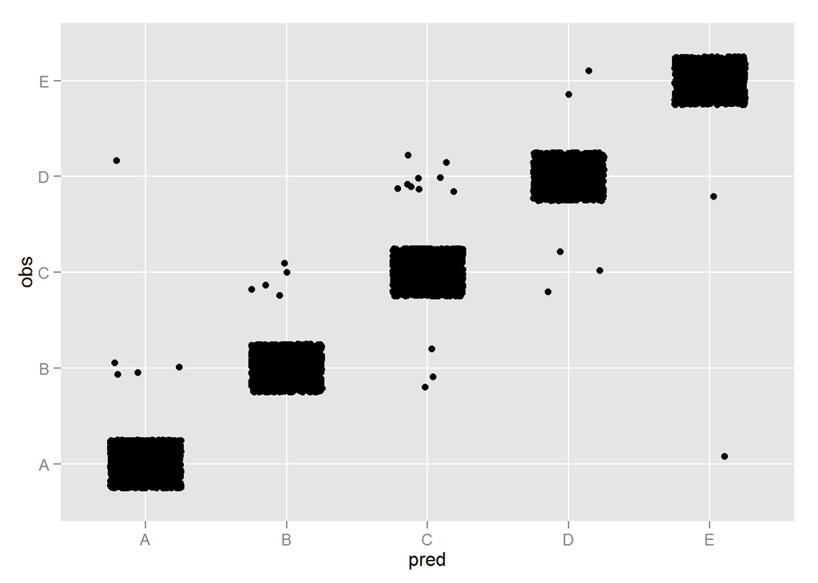

```r
results <- data.frame(pred = predictions, obs = testing$classe)
p <- ggplot(results, aes(x = pred, y = obs))
p <- p + geom_jitter(position = position_jitter(width = 0.25, height = 0.25))
p
```

## Conclusion

The accuracy rate of the chosen model is 98.4%, so we would expect our out of sample error rate to be around 1.6%. Therefore, we should be able to predict exercise form based on accelerometer data with a high degree of accuracy using the given model.